# TP4 : Correction

Kalidou BA (kalidou.ba@u-bordeaux.fr)

24 Septembre 2024

**RMarkdown :** https://www.rstudio.com/wp-content/uploads/2015/02/rmarkdown-cheatsheet.pdf

1. Pour ce TP, créer un RMarkdown qui se sera à compiler au format HTML. L’intégralité du TP sera à effectuer sur ce fichier RMarkdown

# Simulation de données

2. Simuler $n=1000$ réalisations d’une variable aléatoire uniforme sur l’intervalle $[0,1]$. Tracer son histogramme.

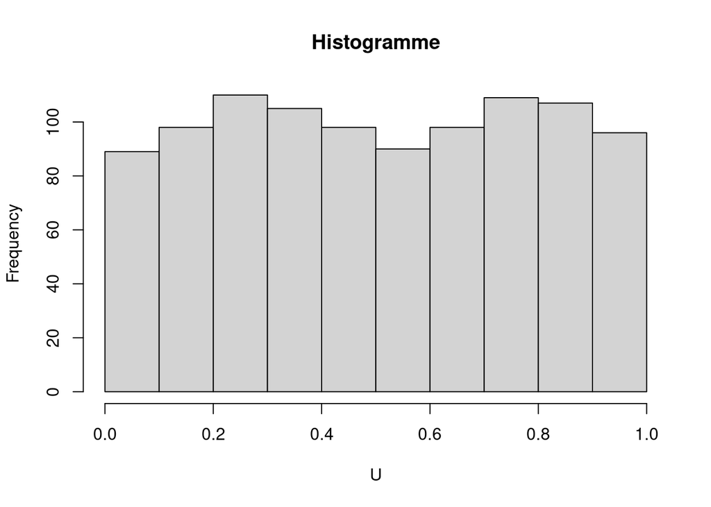

```r
n <- 1000

U <- runif(n)
hist(U, main = "Histogramme")
```

3. Créer une fonction qui prend comme argument x et $\lambda$ (où $\lambda$ prend comme valeur par défaut $1$) et qui renvoie $- \frac{\log(1-x)}{\lambda}$

```r
ma_function <- function(x, lambda = 1){
  return((-log(1-x))/lambda)
}
```

4. Appliquer cette fonction sur les données générées en question 1 avec $\lambda = 1$.

```r
res <- ma_function(U)
```

5. Simuler $n=1000$ réalisations d’une loi exponentielle de paramètre $\lambda=1$.

```r
E <- rexp(n)
```

6. Sur un même graphique, représenter l’estimation de la densité des données générées en 4 et l’estimation de la densité des données générées en 5. Ajouter un titre et une légende. Que remarquez vous ?

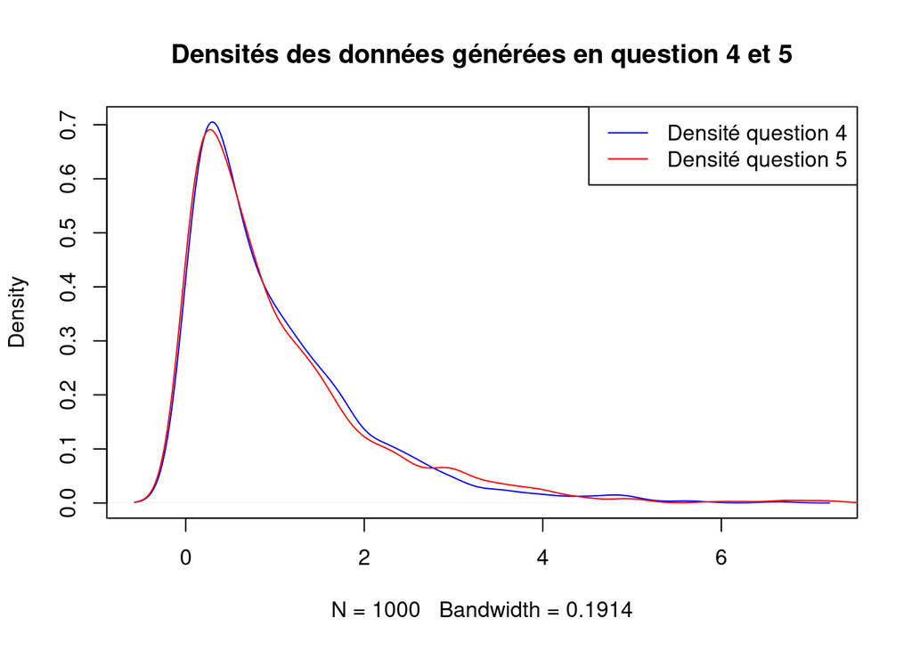

```r
plot(density(res), col="blue", main = "Densités des données générées en question 4 et 5")
lines(density(E), col = "red")
legend('topright', legend=c("Densité question 4", "Densité question 5"), col = c("blue", "red"), lwd=1, cex=1)
```

```r
ccdf_exp <- function(x, lambda=1){
  if (lambda<=0){
    return(warning("lambda doit être strictement positif"))
  }
  else{
    return(1-exp(-lambda*x))
  }
}
```

```r
ccdf_exp(2, lambda = 2)
```

```
## [1] 0.9816844
```

```r
pexp(2, rate = 2)
```

```
## [1] 0.9816844
```

9. Sur une même figure, tracer la fonction de répartition empirique des données générées en 4 et 5 et comparer ces estimations avec la fonction de répartition théorique d’une loi exponentielle de paramètre $\lambda=1$.

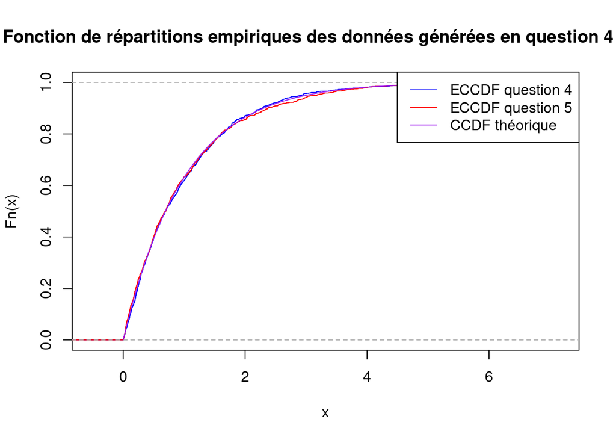

```r
x <- seq(0,6, length.out=100)
plot(ecdf(res), col="blue", main = "Fonction de répartitions empiriques des données générées en question 4 et 5", ylim = c(0,1))
lines(ecdf(E), col = "red")
lines(x, ccdf_exp(x), col = "purple")
legend('topright', legend=c("ECCDF question 4", "ECCDF question 5", "CCDF théorique"), col = c("blue", "red", "purple"), lwd=1, cex=1)
```

10. Donner le médiane théorique (quantile d’ordre $0.5$) d’une loi exponentielle de paramètre $\lambda = 1$ et comparer cette valeur aux médianes calculées à partir des données générées aux questions 4 et 5.

```r
qexp(0.5)
```

```
## [1] 0.6931472
```

```r
median(res)
```

```
## [1] 0.6932445
```

```r
median(E)
```

```
## [1] 0.698671
```

# Modèle linéaire simple

On va maintenant simuler des données selon le modèle linéaire simple :
$$y_i = \beta_0 + \beta_1x_i +
\epsilon_i\text{ avec } \epsilon_i\sim\mathcal{N}(0,\sigma^2)$$
11. Fixer les paramètres $\beta_0=2$ et $\beta_1=5$.

```r
beta0 <-2
beta1 <- 5
```

12. Dans un objet X, simuler $n=1000$ réalisations d’une loi exponentielle de paramètre $\lambda = 0.5$ et dans un objet eps simuler $n=1000$ réalisations d’une loi normale centrée de variance $2$. **Avant de simuler X et eps, on fixera la graine du générateur de nombres aléatoires avec la commande `set.seed(200921)`. Fixer la graine du générateur de nombres aléatoires permet d’obtenir des résultats de simulations qui sont reproductibles dans le sens où, en si l’on se fixe tous la même graine alors nous obtiendrons tous les mêmes résultats de simulations.**

```r
set.seed(200921)
X <- rexp(n, rate = 0.5)
eps <- rnorm(n, sd=sqrt(2))
```

13. Créer un objet $Y = (y_1,\dots, y_n)$ contenant $n =1000$ observations simulées selon le modèle linéaire simple en utilisant X et eps.

```r
Y <- beta0 + beta1*X + eps
```

14. Représenter graphiquement $Y$ en fonction $X$.

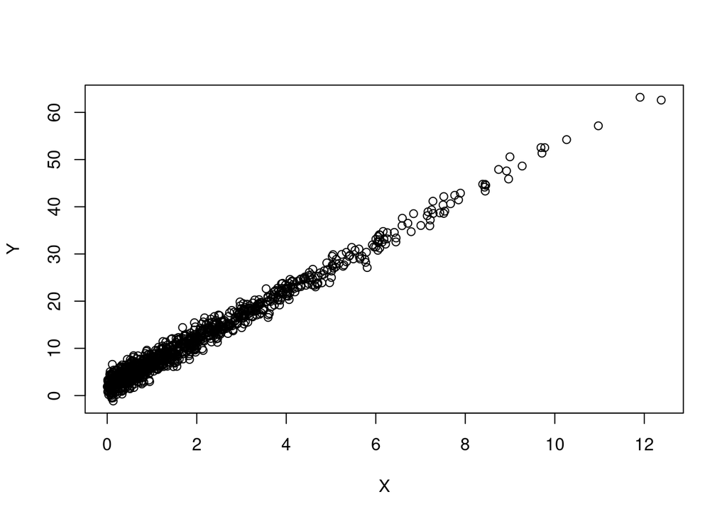

```r
plot(Y~X)
```

15. Tracer l’estimation de la densité de $Y$ et comparer-la à la densité estimée à partir de $n=1000$ réalisations d’une loi normale $\mathcal{N}(\beta_0 + \beta_1x_i, 2)$. Que remarquez-vous ?

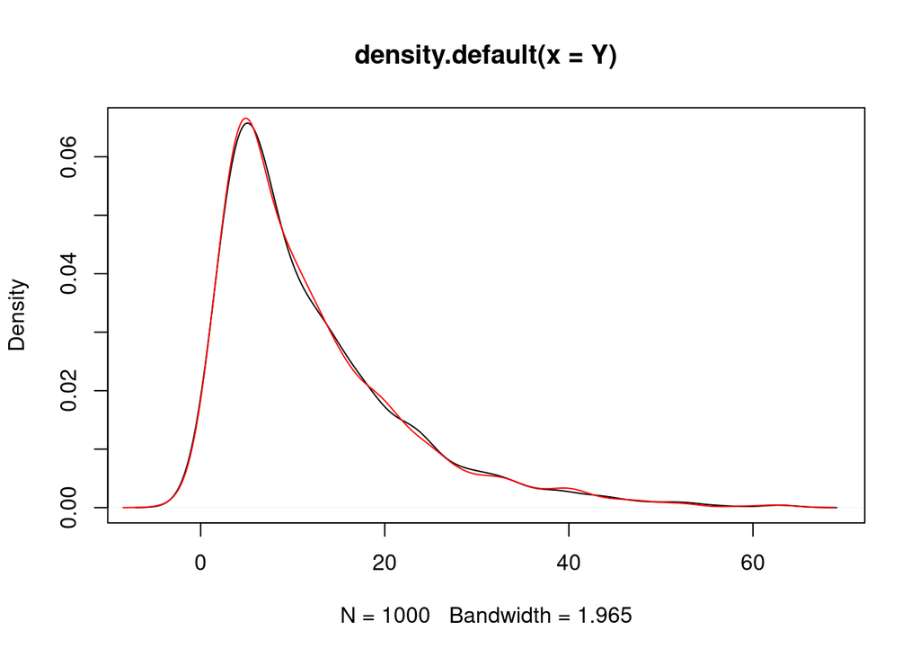

```r
plot(density(Y))
Y.simu <- rnorm(n, beta0 + beta1*X, sd=sqrt(2))
lines(density(Y.simu), col = "red")
```

16. A l’aide de la fonction `lm` effectuer la régression de $Y$ par $X$. Regarder le résultat de cette régression à l’aide de la fonction `summary`.

```r
reg <- lm(Y~X)
summary(reg)
```

```
##
## Call:
## lm(formula = Y ~ X)
##
## Residuals:
##     Min      1Q  Median      3Q     Max
## -4.0987 -0.9402 -0.0153  0.9353  4.1435
##
## Coefficients:
##             Estimate Std. Error t value Pr(>|t|)
## (Intercept)  1.89152    0.06249   30.27   <2e-16 ***
## X            5.04862    0.02214  228.03   <2e-16 ***
## ---
## Signif. codes:  0 '***' 0.001 '**' 0.01 '*' 0.05 '.' 0.1 ' ' 1
##
## Residual standard error: 1.386 on 998 degrees of freedom
## Multiple R-squared:  0.9812, Adjusted R-squared:  0.9812
## F-statistic: 5.2e+04 on 1 and 998 DF,  p-value: < 2.2e-16
```

17. Récupérer dans des objets `beta0_hat` et `beta1_hat` les estimations de $\beta_0$ et $\beta_1$.

```r
beta0_hat <- reg$coefficients[1]
beta1_hat <- reg$coefficients[2]
```

18. Refaire le graphique de la question 14 en y rajoutant la droite de régression estimée.

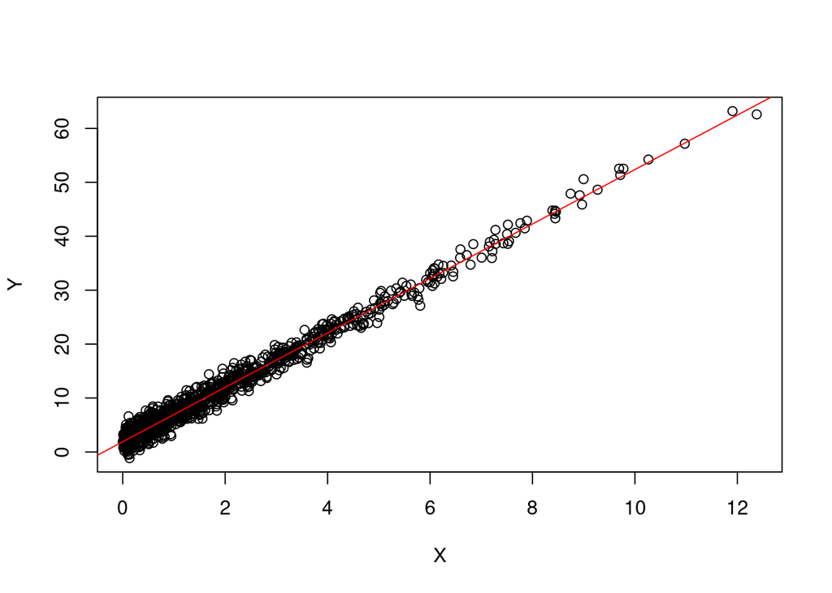

```r
plot(Y~X)
abline(reg, col = "red")
```

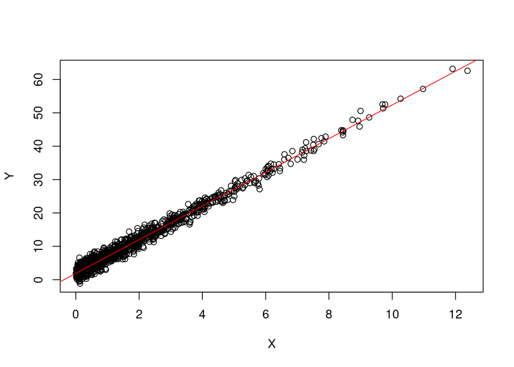

```r
##ou
plot(Y~X)
abline(a=beta0_hat, b = beta1_hat, col = "red")
```

19. Représenter le nuage de points des valeurs prédites de $Y$ par la régression en fonction des vrais valeurs de $Y$ de deux manières différentes. Y ajouter la droite d’équation $y=x$.

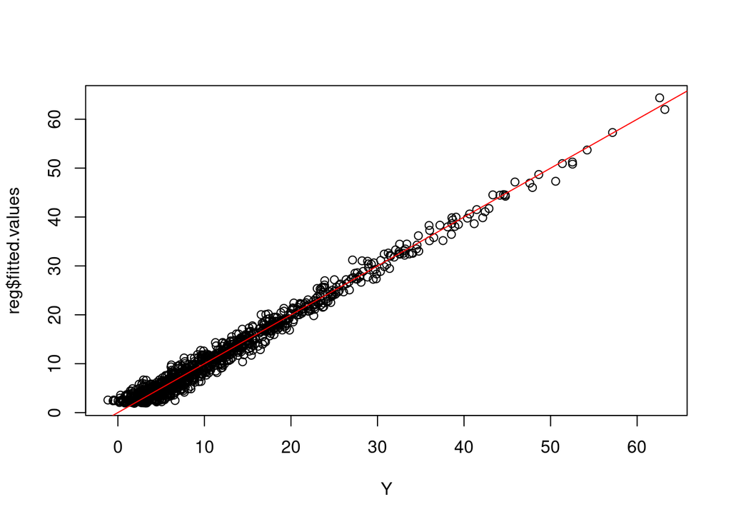

```r
plot(reg$fitted.values~Y)
abline(a=0, b=1, col = "red")
```

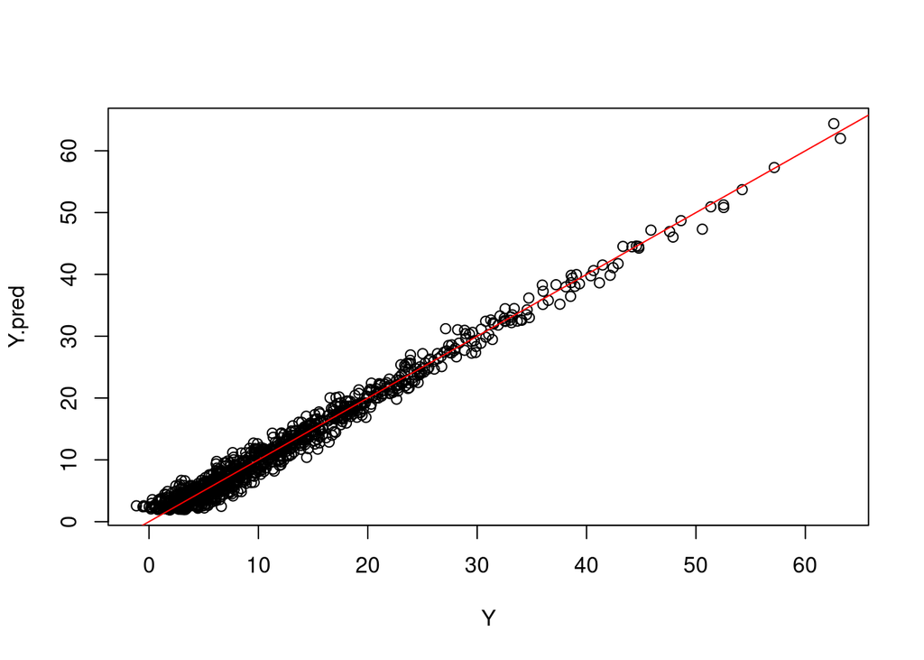

```r
##ou
Y.pred <- predict(reg, new.data=data.frame(Y))
plot(Y.pred~Y)
abline(a=0, b=1, col = "red")
```

20. Calculer le $R^2$ associée à cette régression :

$$R^2 = 1 - \frac{\sum\limits_{i=1}^n(y_i
- \hat{y}_i)^2}{\sum\limits_{i=1}^n(y_i - \overline{y})^2}$$
où :

- $\hat{y}_i$ est la valeur prédite de l’observation $y_i$ par le modèle linéaire
- $\overline{y}$ est la moyenne empirique des $y_i$.

Afficher son arrondi à $10^{-4}$.

Vérifier le calcul en comparant au $R^2$ calculé automatiquement dans R.

```r
meanY <- mean(Y)
R2 <- 1 - sum((Y-Y.pred)^2)/sum((Y-meanY)^2)
round(R2, 4)
```

```
## [1] 0.9812
```

```r
## R2 de R
summreg <- summary(reg)
summreg$r.squared
```

```
## [1] 0.9811689
```

21. On souhaite vérifier numériquement la convergence en loi de l’estimateur des moindre carrés de $\beta_1$ :

$$\hat{\beta_1} \sim
\mathcal{N}\left(\beta_1, \frac{\sigma^2}{\sum\limits_{i=1}^n(x_i -
\overline{x})^2}\right)$$

où :

- $\overline{x}$ correspond à la moyenne empirique de la variable explicative $X$

Pour cela, simuler $N=1000$ fois le vecteur $Y$ issus du modèle linéaire ci-dessus. Pour chaque simulation, on va effectuer la régression de $Y$ par $X$ et pour chaque simulation on sauvegardera dans un vecteur `beta1_simu` l’estimation de $\beta_1$. Ensuite, il ne restera plus qu’à tracer l’histogramme des valeurs prises par $\hat{\beta}_1$ et le comparer à sa densité théorique.

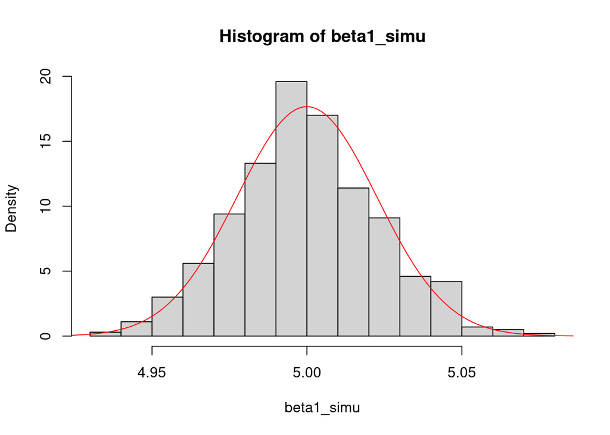

```r
N <- 1000
beta1_simu <- rep(NA, N)
for (i in 1:N){
  eps <- rnorm(n, sd=sqrt(2))
  Y <- beta0 + beta1*X + eps
  reg_simu <- lm(Y~X)
  beta1_simu[i] <- reg_simu$coefficients[2]
}

var_beta1 <- 2/(sum((X-mean(X))^2))
x <- seq(4.9, 5.1, length.out = 1000)
hist(beta1_simu, freq = F)
lines(x, dnorm(x, mean = beta1, sd = sqrt(var_beta1)), col = "red")
```